# Results for VDBA Scaling Analysis

O.W.

2025-11-10

# Compare 5 seconds and 1 second windows

To demonstarte that these are interchangable and results not affected by the length of the window

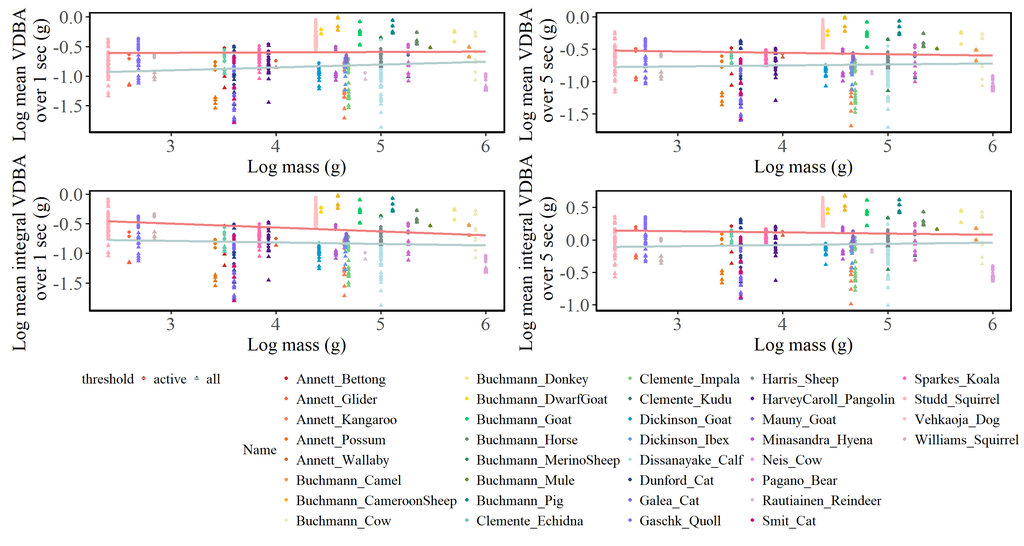

## All species pooled

All species, with approximate/average masses.

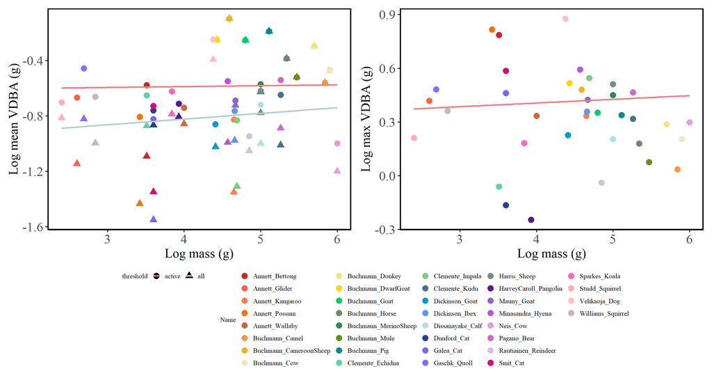

```
## # A tibble: 5 × 9
##   effect term          estimate std.error statistic    df p.value sig   variable
##   <chr>  <chr>            <dbl>     <dbl>     <dbl> <dbl>   <dbl> <chr> <chr>
## 1 fixed  LogMass         0.0663    0.0447     1.48   397. 0.138   not … mean
## 2 fixed  LogMass:thre…   0.0952    0.0300     3.17   336. 0.00164 sig   mean
## 3 fixed  LogMass         0.0338    0.0464     0.729  314. 0.467   not … max
## 4 fixed  LogMass        -0.0992    0.0461    -2.15   393. 0.0321  sig   int
## 5 fixed  LogMass:thre…   0.0951    0.0302     3.15   335. 0.00179 sig   int
```

## Only Datasets With Long Data

Maybe some of the small datasets are skewing it… Exclude datasets that had less than 24 hrs worth of data.

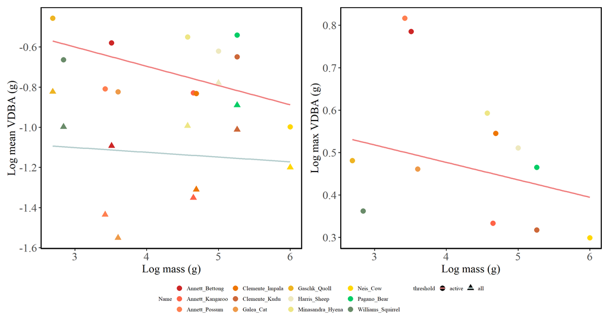

```
## # A tibble: 5 × 9
##   effect term          estimate std.error statistic    df p.value sig   variable
##   <chr>  <chr>            <dbl>     <dbl>     <dbl> <dbl>   <dbl> <chr> <chr>
## 1 fixed  LogMass         -0.219    0.0495     -4.41 145.  1.97e-5 sig   mean
## 2 fixed  LogMass:thre…    0.176    0.0523      3.36 107.  1.07e-3 sig   mean
## 3 fixed  LogMass         -0.115    0.0337     -3.40  84.9 1.02e-3 sig   max
## 4 fixed  LogMass         -0.314    0.0527     -5.95 137.  2.15e-8 sig   int
## 5 fixed  LogMass:thre…    0.176    0.0527      3.34 106.  1.17e-3 sig   int
```

## Collar Data Only

And then only the sepcies that were on a collar.

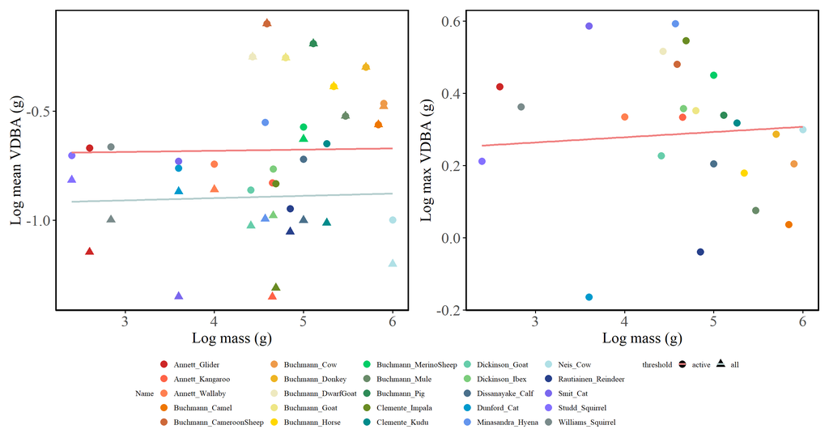

```
## # A tibble: 5 × 9
##   effect term          estimate std.error statistic    df p.value sig   variable
##   <chr>  <chr>            <dbl>     <dbl>     <dbl> <dbl>   <dbl> <chr> <chr>
## 1 fixed  LogMass         0.0267    0.0480     0.557  224. 5.78e-1 not … mean
## 2 fixed  LogMass:thre…   0.0291    0.0338     0.861  180. 3.90e-1 not … mean
## 3 fixed  LogMass         0.0445    0.0376     1.18   177. 2.38e-1 not … max
## 4 fixed  LogMass        -0.196     0.0509    -3.86   219. 1.48e-4 sig   int
## 5 fixed  LogMass:thre…   0.0290    0.0340     0.854  180. 3.94e-1 not … int
```

## Single system analysis

What is the differences in sampling protocol are throwing it out? Collected only data collected in the same way by the same lab. # V1: Clemente There were insufficint individuals, so removed ID as an effect and just had a linear model.

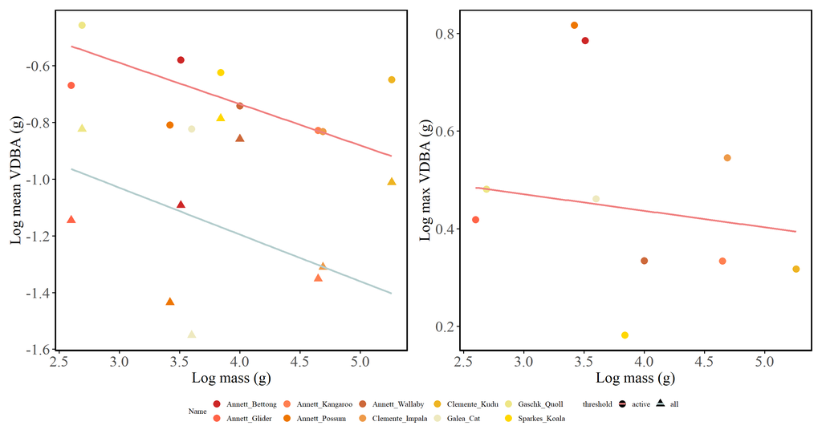

```
## # A tibble: 3 × 7
##   term                 estimate std.error statistic  p.value sig     variable
##   <chr>                   <dbl>     <dbl>     <dbl>    <dbl> <chr>   <chr>
## 1 LogMass               -0.336     0.0868    -3.87  0.000169 sig     mean
## 2 LogMass:thresholdall  -0.0428    0.123     -0.349 0.728    not sig mean
## 3 LogMass               -0.0965    0.0802    -1.20  0.233    not sig max
```

# V2: Buchmann

Similarly ID was not a random effect here as too few individuals.

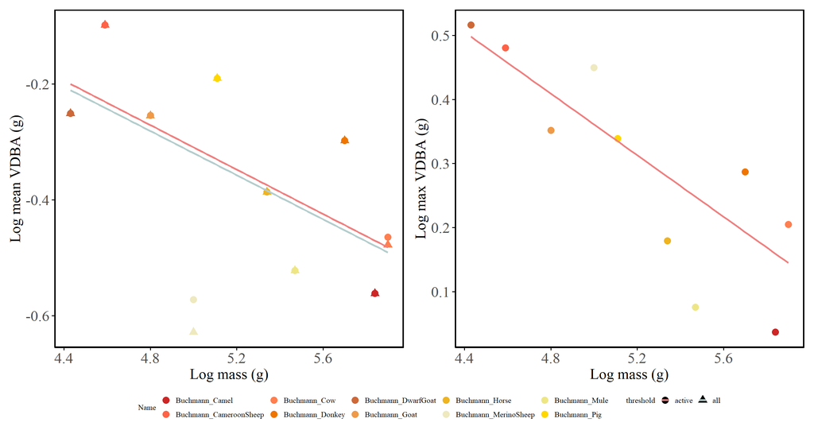

```
## # A tibble: 3 × 7
##   term                 estimate std.error statistic  p.value sig     variable
##   <chr>                   <dbl>     <dbl>     <dbl>    <dbl> <chr>   <chr>
## 1 LogMass              -0.489       0.167   -2.92   0.00463  sig     mean
## 2 LogMass:thresholdall -0.00266     0.237   -0.0113 0.991    not sig mean
## 3 LogMass              -0.602       0.160   -3.75   0.000614 sig     max
```

# Pooled

Maybe the species masses are too vauge… what if we only use the datasets where we know the exact mass? Again, just a linear model with no random effect for ID.

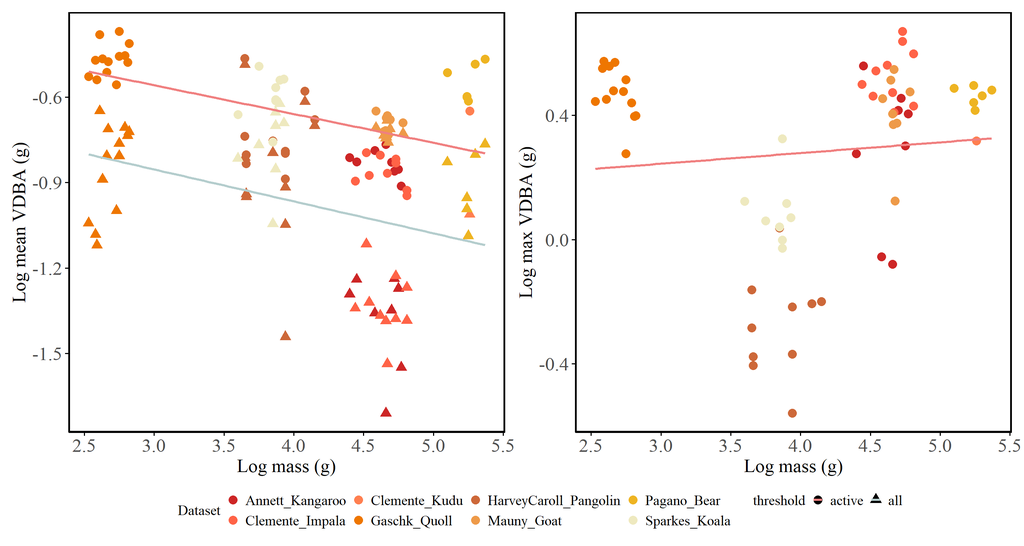

```
## # A tibble: 3 × 7
##   term                 estimate std.error statistic p.value sig     variable
##   <chr>                   <dbl>     <dbl>     <dbl>   <dbl> <chr>   <chr>
## 1 LogMass               -0.233     0.0736    -3.16  0.00196 sig     mean
## 2 LogMass:thresholdall  -0.0254    0.104     -0.244 0.808   not sig mean
## 3 LogMass                0.0795    0.104      0.763 0.448   not sig max
```

# Even further separated

Where the masses of the exact individual are known. Per species plot and then all known individuals on the same graph.

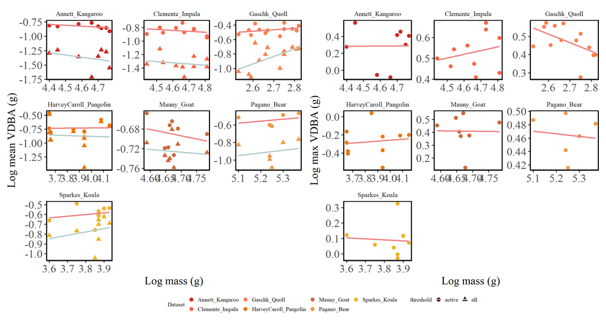

## Understanding the animal activity

# Find the active minutes per day

Is there a mass-mediated effect on activity patterns generally

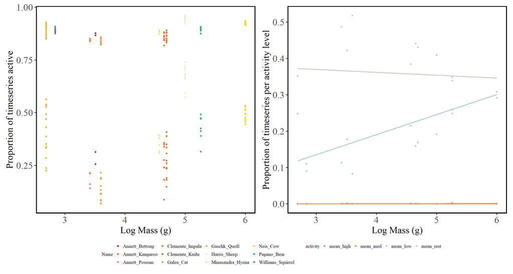

## Understanding the distribution of activity

Does the distibution of high and low VDBA differ with size?

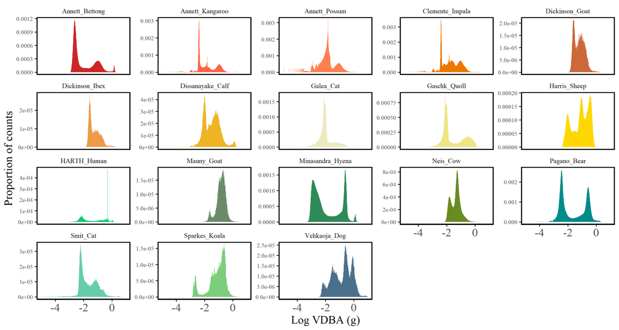